# Link-HD: a versatile framework to explore and integrate heterogeneous data

The correlations between compromise configuration from mixkernel and Link-HD were obtained using procrustes methodology from the vegan library.

```r
mixkCompromise <- as.matrix(meta.kernel$"kernel")
linkhdCompromise <- as.matrix(Output@Compromise.Matrix)

protest(mixkCompromise, linkhdCompromise)
```

```
##
## Call:
## protest(X = mixkCompromise, Y = linkhdCompromise)
##
## Procrustes Sum of Squares (m12 squared):        0.1515
## Correlation in a symmetric Procrustes rotation: 0.9211
## Significance:  0.001
##
## Permutation: free
## Number of permutations: 999
```

Selected variables from mixKernel at family level for 16-S are:

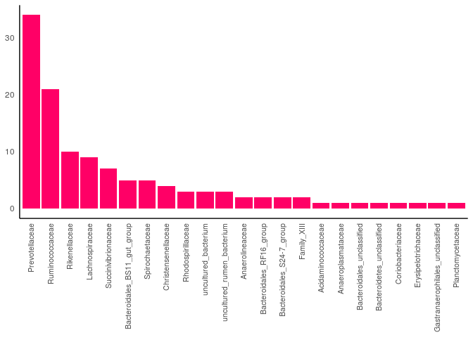

```r
set.seed(17051753)
#Permuting Bacteria
kernel.pca.resultM16 = kernel.pca.permute(kernel.pca.result, ncomp = 1, M16 = colnames(Dataset$'16_S'))
M16relevance <- data.frame(kernel.pca.resultM16$cc.variables, kernel.pca.resultM16$cc.distances)
colnames(M16relevance) <- c("OTU", "Relevance")
M16relevance <- M16relevance[order(-M16relevance[,2]),]
Rel<-M16relevance[1:120,]
melted_Table <- melt(table(Ruminotypes$Taxa_16S[Ruminotypes$Taxa_16S$OTUID%in%Rel$OTU,]$Family))
colnames(melted_Table)<-c("Var1","value")
ggplot(data =melted_Table, aes(x= reorder(Var1, -value), y=value)) +
  scale_fill_gradient(low = "steelblue",
                      high = "#FF0066",na.value="steelblue") +
  geom_bar(stat="identity", fill="#FF0066")+
  theme_classic()+
  theme( axis.ticks = element_blank(),axis.title.x=element_blank(),axis.title.y = element_blank())+
  ggpubr::rotate_x_text(90)+
  theme(axis.text.x=element_text(size=rel(0.9)))
```

Selected variables from mixKernel at genus level for 18-S are:

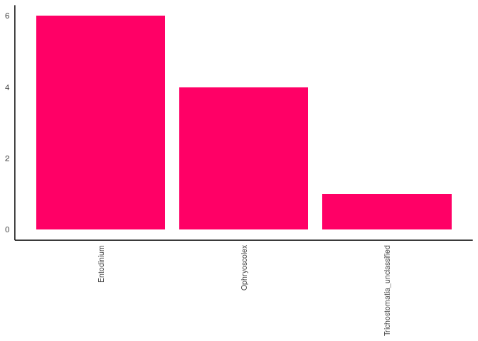

```r
set.seed(17051753)
#Permuting 18S
kernel.pca.resultM18 = kernel.pca.permute(kernel.pca.result, ncomp = 1, M18 = colnames(Dataset$'18_S'))
M18relevance <- data.frame(kernel.pca.resultM18$cc.variables, kernel.pca.resultM18$cc.distances)
colnames(M18relevance) <- c("OTU", "Relevance")
M18relevance <- M18relevance[order(-M18relevance[,2]),]
Rel<-M18relevance[1:11,]
melted_Table <- melt(table(Ruminotypes$Taxa_18S[Ruminotypes$Taxa_18S$OTUID%in%Rel$OTU,]$Genus))
melted_Table <-melted_Table[melted_Table$value>0,]
colnames(melted_Table)<-c("Var1","value")
ggplot(data =melted_Table, aes(x= reorder(Var1, -value), y=value)) +
  scale_fill_gradient(low = "steelblue",
                      high = "#FF0066",na.value="steelblue") +
  geom_bar(stat="identity", fill="#FF0066")+
  theme_classic()+
  theme( axis.ticks = element_blank(),axis.title.x=element_blank(),axis.title.y = element_blank())+
  ggpubr::rotate_x_text(90)+
  theme(axis.text.x=element_text(size=rel(0.9)))
```

Selected variables from mixKernel at genus level for Archaea are:

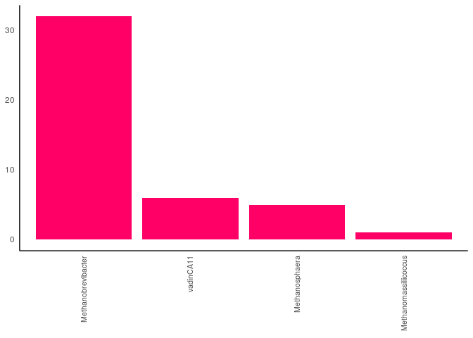

```r
set.seed(17051753)
kernel.pca.resultArch = kernel.pca.permute(kernel.pca.result, ncomp = 1, Arch = colnames(Dataset$'Archaea'))
Archrelevance <- data.frame(kernel.pca.resultArch$cc.variables, kernel.pca.resultArch$cc.distances)
colnames(Archrelevance ) <- c("OTU", "Relevance")
Archrelevance  <- Archrelevance [order(-Archrelevance [,2]),]

Rel<-Archrelevance[1:45,]
melted_Table <- melt(table(Ruminotypes$Taxa_Archaea[which(Ruminotypes$Taxa_Archaea$OTU%in%Rel$OTU),]$Genus))
melted_Table <-melted_Table[melted_Table$value>0,]
#remove one row because it is not classify at genus level
melted_Table<-melted_Table[-1,]
colnames(melted_Table)<-c("Var1","value")
ggplot(data =melted_Table, aes(x= reorder(Var1, -value), y=value)) +
  scale_fill_gradient(low = "steelblue",
                      high = "#FF0066",na.value="steelblue") +
  geom_bar(stat="identity", fill="#FF0066")+
  theme_classic()+
  theme( axis.ticks = element_blank(),axis.title.x=element_blank(),axis.title.y = element_blank())+
  ggpubr::rotate_x_text(90)+
  theme(axis.text.x=element_text(size=rel(0.9)))
```

Despite the agreement between selected variables from mixKernel and Link-HD, their importance is not the same. The discrepancy can be explained by the way in which each package computes the variable weights. Whereas mixkernel only counts the number of OTUs into a genus/family, Link-HD implements a hypergeometric test to establish whether a group of selected OTUs is ‘enriched’ for a particular taxonomic level (i.e., family or genus).

## Alternative omics layers: NCI-60 transcriptome datasets

The following example consists in the illustrative analysis of a subset of NCI-60 cell line panel (Shankavaram et al. 2009,Reinhold et al. (2012)), which is widely used in anti-cancer drug screening. The whole dataset contains 60 human tumour cell lines derived from patients with Leukemia, Melanoma, Lung, Colon, Central Nervous System, Ovarian, Renal, Breast and Prostate cancers. The gene expression of these cell lines was measured using four different microarrays platforms: Agilent mRNA (Whole Human Genome Microarray, $4 \times 44K$) and Affymetrix (HGU 95, HGU 133 and HGU 133plus 2.0). The toy dataset we use here is freely available in the omicade4 package (Meng et al. 2013).

```r
library(omicade4)
data(NCI60_4arrays)
#check data dimensions
lapply(NCI60_4arrays, dim)
```

```
## $agilent
## [1] 300  60
##
## $hgu133
## [1] 298  60
##
## $hgu133p2
## [1] 268  60
##
## $hgu95
## [1] 288  60
```

As Link-HD requires common elements in rows, matrices need to be transpose:

```r
data<-lapply(NCI60_4arrays, function(x){t(x)})
lapply(data,dim)
```

```
## $agilent
## [1]  60 300
##
## $hgu133
## [1]  60 298
##
## $hgu133p2
## [1]  60 268
##
## $hgu95
## [1]  60 288
```

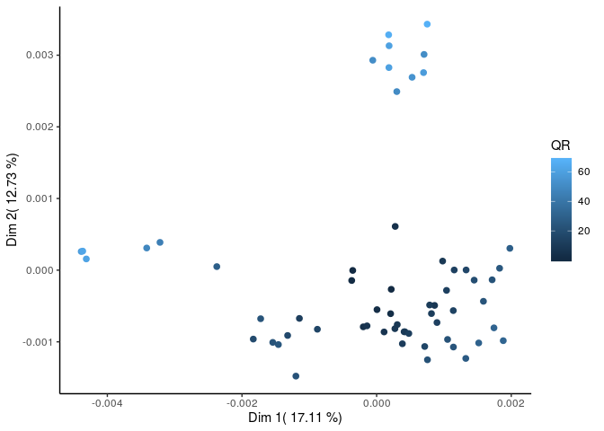

```r
Output<-LinkData(data,Distance=rep("euclidean",3),Scale = TRUE,Center=TRUE,nCluster = 9)
#variance explained by compromise coordinates
CompromisePlot(Output)+theme(panel.grid.major = element_blank(),
panel.grid.minor = element_blank(),
panel.background = element_blank(),
axis.line = element_line(colour="black"))
```

Note that Link-HD proportion of explained variance by the two first components (PC1=17.11% and PC=12.73%) is simmilar to the one reported by (Meng et al. 2013).

In order to better undestand the samples structure, we can color them by tumoral tissues:

```r
cancer_type <- rownames(data$agilent)
#To select strings before the "."
cancer_type <- sapply(strsplit(cancer_type, split="\\."),function(x){x[1]})
```

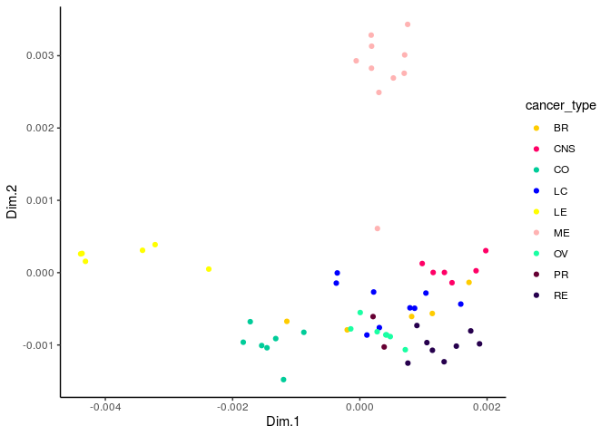

```r
mydata=compromise_coords(Output)
#set colors
cols <- c("#ffcc00","#ff0066","#00cc99","#0000ff","#ffff00","#ffb3b3","#1affa3","#660033","#26004d")
mydata$fit.cluster<-as.factor(mydata$fit.cluster)
p<-ggplot(mydata, aes(Dim.1,Dim.2)) +
geom_point(aes(colour = cancer_type))
p + scale_colour_manual(values = cols) + theme_classic()
```

Meanwhile, the next figure represents the color according to the Link-HD clusters assignation:

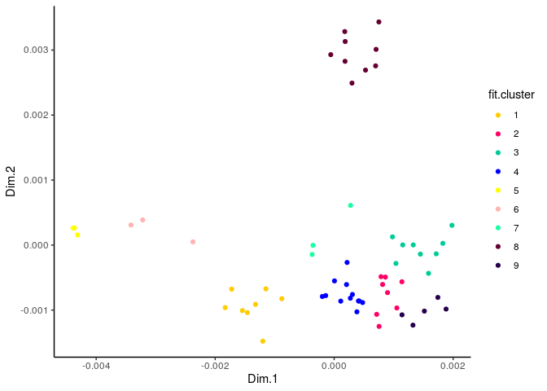

```r
mydata=compromise_coords(Output)
#set colors
cols <- c("#ffcc00","#ff0066","#00cc99","#0000ff","#ffff00","#ffb3b3","#1affa3","#660033","#26004d")
mydata=compromise_coords(Output)
mydata$fit.cluster<-as.factor(mydata$fit.cluster)
p<-ggplot(mydata, aes(Dim.1,Dim.2)) +
geom_point(aes(colour = fit.cluster))
p + scale_colour_manual(values = cols) + theme_classic()
```

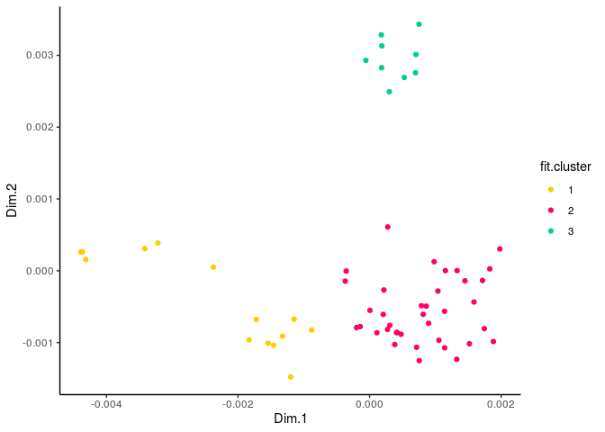

```r
Output<-LinkData(data,Distance=rep("euclidean",3),Scale = TRUE,Center=TRUE,nCluster = 3)
mydata=compromise_coords(Output)
#set colors
cols <- c("#ffcc00","#ff0066","#00cc99")
mydata=compromise_coords(Output)
mydata$fit.cluster<-as.factor(mydata$fit.cluster)
p<-ggplot(mydata, aes(Dim.1,Dim.2)) +
geom_point(aes(colour = fit.cluster))
p + scale_colour_manual(values = cols) + theme_classic()
```

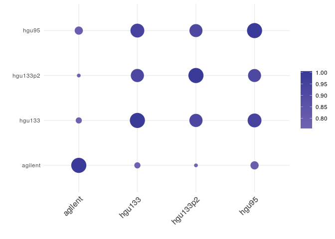

```r
CorrelationPlot(Output)
```

We also apply Select_Var function in order to select the most important variables, responsible of the obtained structure.

```r
Select_Var<-VarSelection(Output,Data=data,Crit = "Rsquare",perc=0.9)
```

```r
Variables(Select_Var)
```

```
##   [1] "LHFP"       "WWC2"       "LEPREL1"
##   [4] "PVR"        "VAMP3"      "LOC344978"
##   [7] "BACE1"      "FERMT1"     "FKBP10"
##  [10] "TBC1D2"     "SYNM"       "KRT8P23"
##  [13] "HERC1"      "SC65"       "ANXA3"
##  [16] "MLF1"       "PTGES"      "TOR2A"
##  [19] "OCLN"       "PPIC"       "GPC6"
##  [22] "GMFG"       "ETV3"       "C9orf30"
##  [25] "C19orf39"   "S100B"      "PTPN21"
##  [28] "SMAD3"      "BACE2"      "GNPTAB"
##  [31] "CA12"       "HSPBAP1"    "ARAP3"
##  [34] "ZFP36"      "PDLIM2"     "DUSP4"
##  [37] "FAM57A"     "HELZ"       "ECHDC2"
##  [40] "SPEG"       "C1orf131"   "ATP1A3"
##  [43] "C10orf90"   "C3orf59"    "PRKD1"
```

[output cut: 27 more lines]

Finally, to gain insight into the overrepresented biological processes, we carry out a classical set enrichment analyses, Gene Ontology (GO) approach by using the Functional Gene Networks (FGNet) Bioconductor package (Aibar et al. 2015).

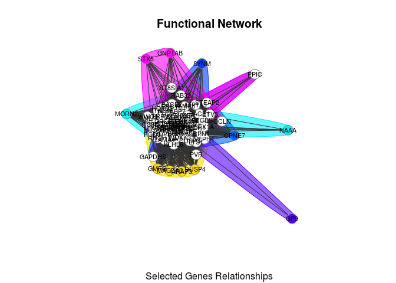

```r
library(FGNet)
library("org.Hs.eg.db")
List<-union(union(union(toupper(colnames(data[[1]])),toupper(colnames(data[[2]]))),toupper(colnames(data[[3]]))),toupper(colnames(data[[4]])))
##hay 22756 genes distintos

geneLabels<-List
feaResults_topGO <- fea_topGO(Variables(Select_Var),genesUniverse = List ,geneIdType="SYMBOL", organism="Hs")
feaResults <- feaResults_topGO
incidMat <- fea2incidMat(feaResults)
functionalNetwork(incidMat, plotTitleSub="Selected Genes Relationships",legendText = FALSE)
```

The Gene Enrichment Analysis returns a list with the top Gene Ontology (GO) terms. Between the top 5 of enriched biological processes, we can highlight: Angiogenesis Regulation, which is essential for tumor development and metastasis, Epithelial cell proliferation and Regulation of epithelial cell proliferation, that are involve in colonorectal neoplasms. External tools for Gene Enrichment Analysis are also available. For instance,the results from IPA (Ingenuity Pathway Analysis) reveals several cancer - related pathways, such as the Regulation of the Epithelial-Mesenchymal Transition (EMT), which is crucial in the metastasis development. Moreover, biological functions related with Carcinomas and digestive cancer (Organismal Injury and Abnormalities Carcinoma,Gastrointestinal Disease, Organismal Injury and Abnormalities Digestive system cancer) were also identified.

## Final Remarks

In summary, we have developed Link-HD, an R package to integrate heterogeneous variable datasets. It combines some well-known multivariate techniques to perform data integration with cluster, variable selection and network analysis. We show the utility of Link-HD to integrate heterogeneous datasets. Applied to data from the TARA Ocean expedition, Link-HD reproduces the relevance of members of Proteobacteria phyla and temperature on the functionality and stratification of this ecosystem. Regarding the rumen microbiota, the consensus space inferred by Link-HD shows the association of the structure of the rumen microbiome with $CH_4$ emission. The method also facilitates the study of the relationships between observations and features for performing variable selection. In this sense, a good performance of Link-HD with other available integrative methodologies, such as mixKernel was demonstrated. Finally, as is illustrated in the last example, our approach can also be used to integrate and explore others kind of ‘omics’ data.

## Appendix

List of LinkHD dependencies:

```
methods,
scales,
ggplot2,
dplyr,
cluster,
graphics,
ggpubr,
reshape,
gridExtra,
vegan,
data.table,
rio,
MultiAssayExperiment
```

## References

Aibar, Sara, Celia Fontanillo, Conrad Droste, and Javier De Las Rivas. 2015. “Functional Gene Networks: R/Bioc Package to Generate and Analyze Gene Networks Derived from Functional Enrichment and Clustering.” *Bioinformatics* 31 (10): 1686–8. doi:10.1093/bioinformatics/btu864.

Aitchison, John. 1982. “The Statistical Analysis of Compositional Data.” *Journal of the Royal Statistical Society: Series B (Methodological)* 44 (2). Wiley Online Library: 139–60.

Aitchison, John, Jim W Kay, and others. 2003. “Possible Solution of Some Essential Zero Problems in Compositional Data Analysis.” Universitat de Girona. Departament d’Informàtica i Matemàtica Aplicada.

Argelaguet, Ricard, Britta Velten, Damien Arnol, Sascha Dietrich, Thorsten Zenz, John C Marioni, Florian Buettner, Wolfgang Huber, and Oliver Stegle. 2018. “Multi-Omics Factor Analysis—a Framework for Unsupervised Integration of Multi-Omics Data Sets.” *Molecular Systems Biology* 14 (6). EMBO Press: e8124.

Benjamini, Yoav, and Yosef Hochberg. 1995. “Controlling the False Discovery Rate: A Practical and Powerful Approach to Multiple Testing.” *Journal of the Royal Statistical Society: Series B (Methodological)* 57 (1). Wiley Online Library: 289–300.

Berry, David, and Stefanie Widder. 2014. “Deciphering Microbial Interactions and Detecting Keystone Species with Co-Occurrence Networks.” *Frontiers in Microbiology* 5. Frontiers: 219.

Danielsson, Rebecca, Johan Dicksved, Li Sun, Horacio Gonda, Bettina Müller, Anna Schnürer, and Jan Bertilsson. 2017. “Methane Production in Dairy Cows Correlates with Rumen Methanogenic and Bacterial Community Structure.” *Frontiers in Microbiology* 8. Frontiers: 226.

Escoufier, Y, P Cazes, and others. 1976. “Opérateurs et Analyse Des Tableaux à Plus de Deux Dimensions.” *Cahiers Du Bureau Universitaire de Recherche Opérationnelle* 25: 61–89.

Faust, Karoline, and Jeroen Raes. 2012. “Microbial Interactions: From Networks to Models.” *Nature Reviews Microbiology* 10 (8). Nature Publishing Group: 538.

Gabriel, K. R. 1971. “The Biplot Graphic Display of Matrices with Application to Principal Component Analysis.” *Biometrika* 58 (3): 453. doi:10.2307/2334381.

Gower, John C, and David J Hand. 1995. *Biplots*. Vol. 54. CRC Press.

Greenacre, Michael J. 2010. *Biplots in Practice*. Fundacion BBVA.

Kittelmann, Sandra, Henning Seedorf, William A Walters, Jose C Clemente, Rob Knight, Jeffrey I Gordon, and Peter H Janssen. 2013. “Simultaneous Amplicon Sequencing to Explore Co-Occurrence Patterns of Bacterial, Archaeal and Eukaryotic Microorganisms in Rumen Microbial Communities.” *PloS One* 8 (2). Public Library of Science: e47879.

Kruskal, William H, and W Allen Wallis. 1952. “Use of Ranks in One-Criterion Variance Analysis.” *Journal of the American Statistical Association* 47 (260). Taylor & Francis Group: 583–621.

Kurtz, Zachary D, Christian L Müller, Emily R Miraldi, Dan R Littman, Martin J Blaser, and Richard A Bonneau. 2015. “Sparse and Compositionally Robust Inference of Microbial Ecological Networks.” *PLoS Computational Biology* 11 (5). Public Library of Science: e1004226.

Lavit, Christine. 1988. “Presentation de La Méthode Statis Permettant L’analyse Conjointe de Plusieurs Tableaux de Données Quantitatives.” *Cachiers de La Recherche Dévelopment* 18: 49–60.

Lavit, Christine, Yves Escoufier, Robert Sabatier, and Pierre Traissac. 1994. “The ACT (STATIS method).” *Computational Statistics & Data Analysis* 18 (1): 97–119. doi:10.1016/0167-9473(94)90134-1.

Lima-Mendez, Gipsi, Karoline Faust, Nicolas Henry, Johan Decelle, Sébastien Colin, Fabrizio Carcillo, Samuel Chaffron, et al. 2015. “Determinants of Community Structure in the Global Plankton Interactome.” *Science* 348 (6237). American Association for the Advancement of Science: 1262073.

Mariette, Jérôme, and Nathalie Villa-Vialaneix. 2017. “Unsupervised Multiple Kernel Learning for Heterogeneous Data Integration.” *Bioinformatics* 34 (6). Oxford University Press: 1009–15.

Meng, Chen, Bernhard Kuster, Aedin Culhane, and Amin Moghaddas Gholami. 2013. “A Multivariate Approach to the Integration of Multi-Omics Datasets.” *BMC Bioinformatics*.

Park, Hae-Sang, and Chi-Hyuck Jun. 2009. “A Simple and Fast Algorithm for K-Medoids Clustering.” *Expert Systems with Applications* 36 (2). Elsevier: 3336–41.

Paulson, Joseph N, O Colin Stine, Héctor Corrada Bravo, and Mihai Pop. 2013. “Differential Abundance Analysis for Microbial Marker-Gene Surveys.” *Nature Methods* 10 (12). Nature Publishing Group: 1200.

Pawlowsky-Glahn, Vera, and Antonella Buccianti. 2011. *Compositional Data Analysis*. Wiley Online Library.

Plantes, Henri L’Hermier des. 1976. “Structuration Des Tableaux à Trois Indices de La Statistique: Théorie et Application d’une Méthode d’analyse Conjointe.” PhD thesis, Université des sciences et techniques du Languedoc.

Ramayo-Caldas, Yuliaxis, Nuria Mach, Patricia Lepage, Florence Levenez, Catherine Denis, Gaetan Lemonnier, Jean-Jacques Leplat, et al. 2016. “Phylogenetic Network Analysis Applied to Pig Gut Microbiota Identifies an Ecosystem Structure Linked with Growth Traits.” *The ISME Journal* 10 (12). Nature Publishing Group: 2973.

Ramayo-Caldas, Yuliaxis, Laura Zingaretti, Milka Popova, Jordi Estellé, Aurelien Bernard, Nicolas Pons, Pau Bellot, et al. 2019. “Identification of Rumen Microbial Biomarkers Linked to Methane Emission in Holstein Dairy Cows.” *Journal of Animal Breeding and Genetics*. Wiley Online Library.

Reinhold, William C, Margot Sunshine, Hongfang Liu, Sudhir Varma, Kurt W Kohn, Joel Morris, James Doroshow, and Yves Pommier. 2012. “CellMiner: a web-based suite of genomic and pharmacologic tools to explore transcript and drug patterns in the NCI-60 cell line set.” *Cancer Research* 72 (14): 3499–3511. doi:10.1158/0008-5472.CAN-12-1370.

Robert, Paul, and Yves Escoufier. 1976. “A unifying tool for linear multivariate statistical methods: the RV-coefficient.” *Applied Statistics*. JSTOR, 257–65.

Rohart, Florian, Benoit Gautier, Amrit Singh, and Kim-Anh Lê Cao. 2017. “MixOmics: An R Package for ‘Omics Feature Selection and Multiple Data Integration.” *PLoS Computational Biology* 13 (11). Public Library of Science: e1005752.

Rousseeuw, Peter J. 1987. “Silhouettes: A Graphical Aid to the Interpretation and Validation of Cluster Analysis.” *Journal of Computational and Applied Mathematics* 20. Elsevier: 53–65.

Shankavaram, Uma T, Sudhir Varma, David Kane, Margot Sunshine, Krishna K Chary, William C Reinhold, Yves Pommier, and John N Weinstein. 2009. “CellMiner: a relational database and query tool for the NCI-60 cancer cell lines.” *BMC Genomics* 10 (January): 277. doi:10.1186/1471-2164-10-277.